# Gender-based Income Gap Analysis

**Residuals vs. Fitted**

There is a indication of non-linearity present in this plot. Furthermore, we see that the variance appears to be increasing across fitted value.

**Normal QQ plot**

**Scale-location plot**

We see a clear increasing trend in residual variance that runs through most of the plot. This is indicated by the upward slope of the red line, which we can interpret as the standard deviation of the residuals at the given level of fitted value.

**Residuals vs Leverage.**

|  | Estimate | Std. Error | t value | Pr(>\|t\|) |
| --- | --- | --- | --- | --- |
| (Intercept) | 14836.5031903632 | 10742.8638045445 | 1.3810566214278 | 0.167311406690032 |
| genderMALE | 4115.96589719882 | 11856.6351537472 | 0.347144518139113 | 0.728494551470535 |
| occupation.2011Construction Trade and Extraction Workers | -8402.14541164154 | 12696.8760548901 | -0.661749029865145 | 0.508156709376485 |
| occupation.2011Counselors, Sociala and Religious Workers | -9220.66931358947 | 10828.3672663315 | -0.851529052053781 | 0.394508472861306 |
| occupation.2011Education, Training and Library Workers | -12993.0770787252 | 10849.3782119078 | -1.19758725568849 | 0.231123596437321 |
| occupation.2011Engineers, Architects, Surveyers, Engineering and Related Technicians | 1167.32039182288 | 14669.9553767986 | 0.0795721842255269 | 0.936580091039413 |
| occupation.2011Entertainers and Performers, Sports and Related Workers | -21493.4868461749 | 11679.7589045393 | -1.84023377724188 | 0.0657817669571153 |
| occupation.2011Entertainment Attendants and Related Workers | -17036.3187545883 | 13394.3037969572 | -1.27190774622108 | 0.203453681302702 |
| occupation.2011Executive, Administrative and Managerial Occupations | 17496.9883666834 | 10518.5155872616 | 1.66344654067662 | 0.0962737052042357 |
| occupation.2011Farming, Fishing and Forestry Occupations | -18963.6625760773 | 15913.5806213717 | -1.1916653471821 | 0.233438177362507 |

[output cut: 70 more lines]

Though, we see very high estimate values in most of the coefficients, they are not highly significant.

Interpretation of Output 27 coefficients are positively associated and 2 coefficients are negatively assciated with the intercept. Also, looking at the P-value, it can be identified that 28 coefficients are not significant. Only one coefficient is signficant. There is only one significant predictor variable associated with interaction term. All the other values have p-value >0.05.

```
## Analysis of Variance Table
##
## Model 1: total.income.2011 ~ gender + occupation.2011 + highest.2011.grade +
##     region.current.2011
## Model 2: total.income.2011 ~ gender + occupation.2011 + highest.2011.grade +
##     region.current.2011 + gender:occupation.2011
##   Res.Df           RSS Df   Sum of Sq      F  Pr(>F)
## 1   6219 5355557463840
## 2   6190 5318285175883 29 37272287957 1.4959 0.04248 *
## ---
## Signif. codes:  0 '***' 0.001 '**' 0.01 '*' 0.05 '.' 0.1 ' ' 1
```

On comparing two models (the one with interaction variable and the one without, we found that p-value is slightly statistically significant, here it is 0.04248, so we can reject the null hypothesis that the income gap is the same across all the occupation categories. In other words, all other variables kept same, the data suggests that the income gap between men and women does vary with occupation.

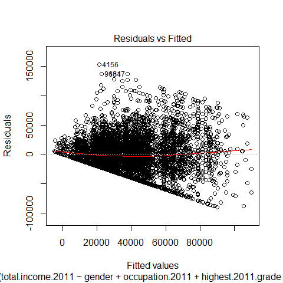

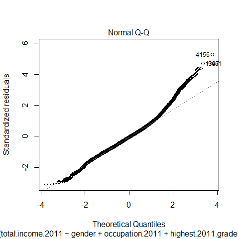

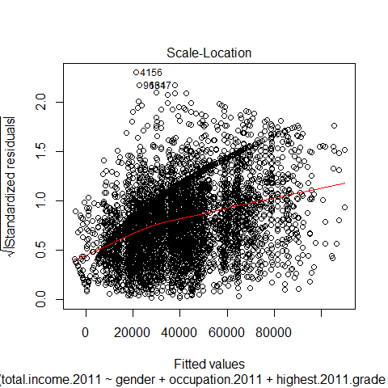

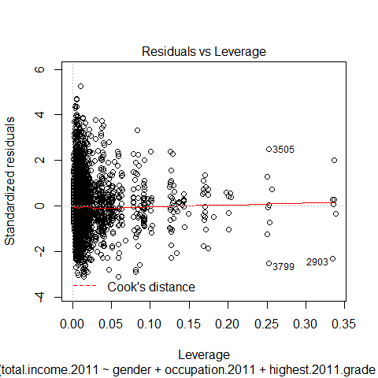

**Description of Diagnostic Plots**

**Residuals vs. Fitted**

There is a indication of non-linearity present in this plot. Furthermore, we see that the variance appears to be increasing across fitted value.

**Normal QQ plot**

**Scale-location plot**

We see a clear increasing trend in residual variance that runs through most of the plot. This is indicated by the upward slope of the red line, which we can interpret as the standard deviation of the residuals at the given level of fitted value.

**Residuals vs Leverage.**

|  | Estimate | Std. Error | t value | Pr(>\|t\|) |
| --- | --- | --- | --- | --- |
| (Intercept) | 8366.9362642317 | 6502.38677975586 | 1.28674847369597 | 0.198230027976431 |
| raceHISPANIC | 5080.20047074254 | 1155.77435037269 | 4.39549508007718 | 1.12365239242402e-05 |
| raceOTHERS | 7480.87822453959 | 887.241005752619 | 8.4316191159287 | 4.1973101158916e-17 |
| genderMALE | 8864.12839474542 | 5286.51656467076 | 1.67674276365338 | 0.0936432234414391 |
| family.size.2011 | 1140.28031278415 | 265.615043776234 | 4.29298091167146 | 1.78977658714813e-05 |
| num.job.2011 | -654.794340528533 | 52.9763127484792 | -12.3601343045025 | 1.09755618997499e-34 |
| occupation.2011Construction Trade and Extraction Workers | -297.388425651871 | 5162.02336620391 | -0.0576108251657465 | 0.954060483890235 |
| occupation.2011Counselors, Sociala and Religious Workers | 1400.22985541438 | 5606.95039036507 | 0.24973109407576 | 0.802803586372605 |
| occupation.2011Education, Training and Library Workers | -5471.40274868856 | 5834.73599024839 | -0.937729274783457 | 0.348420093597384 |
| occupation.2011Engineers, Architects, Surveyers, Engineering and Related Technicians | 26710.3634499619 | 5853.24632582979 | 4.56334177020566 | 5.13166175475507e-06 |

[output cut: 62 more lines]

Interpretation of Coefficients

There are 17 estimated coefficients for this interaction term. These coefficients correspond to differences in earnings across gender and highest grade attained that aren’t accounted for by a model that assumes independent effects for race and highes grade (as in nlsy.lm1). That is, the income difference between men and women appears to depend on the individual’s highest grade attacined. For instance, the income difference among men and women having ‘4th Year College’ education is $12891 more than the difference between men and women having highest degree to 1st grade only. Highest degree is a factor that is slightly associated with the income gap between men and women.

Though, we see very high estimate values in most of the coefficients, they are not that highly significant.

Interpretation of Output

```
## Analysis of Variance Table
##
## Model 1: total.income.2011 ~ race + gender + family.size.2011 + num.job.2011 +
##     occupation.2011 + highest.2011.grade + +region.current.2011
## Model 2: total.income.2011 ~ race + gender + family.size.2011 + num.job.2011 +
##     occupation.2011 + highest.2011.grade + region.current.2011 +
##     gender:highest.2011.grade
##   Res.Df           RSS Df   Sum of Sq      F  Pr(>F)
## 1   6215 5140505700374
## 2   6198 5113138566294 17 27367134080 1.9514 0.01087 *
## ---
## Signif. codes:  0 '***' 0.001 '**' 0.01 '*' 0.05 '.' 0.1 ' ' 1
```

On comparing two models (the one with interaction variable and the one without, we found that p-value is statistically significant, here it is 0.01087, so we can reject the null hypothesis that the income gap is the same across all the highest grade categories. In other words, all other variables kept same, the data suggests that the income gap between men and women does vary with highest grade

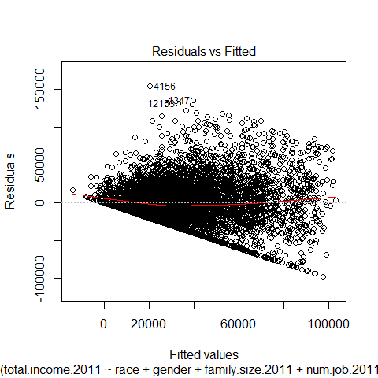

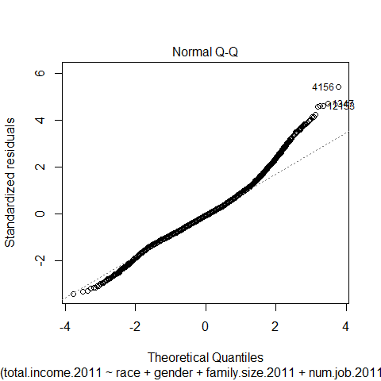

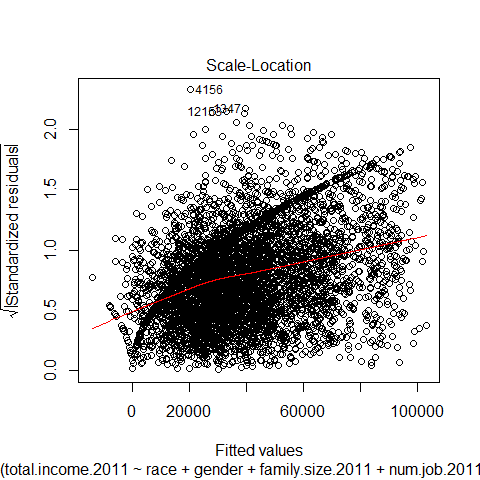

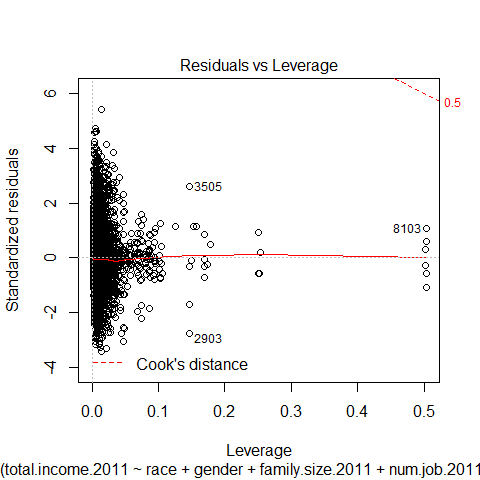

**Description of Diagnostic Plots**

**Residuals vs. Fitted**

There is a indication of non-linearity present in this plot. Furthermore, we see that the variance appears to be increasing across fitted value.

**Normal QQ plot**

**Scale-location plot**

We see a clear increasing trend in residual variance that runs through most of the plot. This is indicated by the upward slope of the red line, which we can interpret as the standard deviation of the residuals at the given level of fitted value.

**Residuals vs Leverage.**

### Discussion

#### Summary of the main conclusions

Non-factor variables such as family size and number of jobs changed also reflect on income gap.

In our conclusion, I can say that, income gap is more or little affected by race, gender, highest grade, occupation. family size, and number of jobs changed by a person.

#### Potential limitations of analysis and findings

A imitation of the analysis is that it is focused on few variables, that too preferably latest one. There is no trend analysis done in it. There was no analysis done to map highest grade and occupation against income and gender to check how in combination they impact salary gap.

Another limitation of the analysis is that it doesnot include any experience information. There may be a case that our sample has women with less number of experience and men with more experience. Hence, the analysis has its limitation of not going in depth categories to provide a comprehensive outcome.

The findings is also based on few latest variables in the model. It doesnot give the holistic picture of the scenario.